# NYISO Zonal Price Spread Analysis

## Overview

Electricity pricing in New York varies due to transmission congestion. The 11 zones have varying traits such as population and environmental factors which influences energy production capacity and demand. For example, Zone A (West) has vast hydroelectric resources but sparse population compared to Zone J (N.Y.C) which, given its high demand, consistently has the most expensive utility rates. This project investigates the price spread between these two zones in NYISO’s 2025 day-ahead market, offering an examination of when congestion peaks and why.

## Hypotheses

I’m expecting to see peak price spread during the hottest and coldest months of the year as these are moments with the most usage of climate control technology which is extremely energy intensive. I’m also anticipating a larger price spread during evening hours as people return home from work, school, etc., with a drop-off around midnight as people sleep. Due to the rise in remote-work culture, I’m not anticipating a significant spike on weekends.

## Data

- **Source:** NYISO Market Information System (MIS), Day-Ahead Market Zonal LBMP
- **Coverage:** Full year 2025, all 11 internal NY zones, hourly resolution
- **Pipeline:** 365 daily CSVs downloaded, cleaned, and combined with timezone handling for daylight savings

## Method

1. Manually downloaded CSVs by month, cleaned, and combined a full year of NYISO zonal LBMP data
2. Engineered the NYC-WEST spread as the key variable of interest
3. Explored seasonal and daily patterns visually
4. Trained a Random Forest regression model using time features (hour, month, day of week) to assess how well different temporal features predict congestion

## Model Results

The random forest shows **month is the strongest predictor** spread magnitude, followed by hour of day, and day of week. However, the model’s **R² = -0.715** indicating that time features alone aren’t reliable predictors of spread.  
Real-time conditions such as load levels and generation mix are likely also significant drivers rather than just schedule alone. However, this in-and-of-itself is an insight: congestion in NYISO is structurally seasonal but operationally noisy!

## Charts

- **Average spread by month** — winter dominance of the NYC-WEST spread

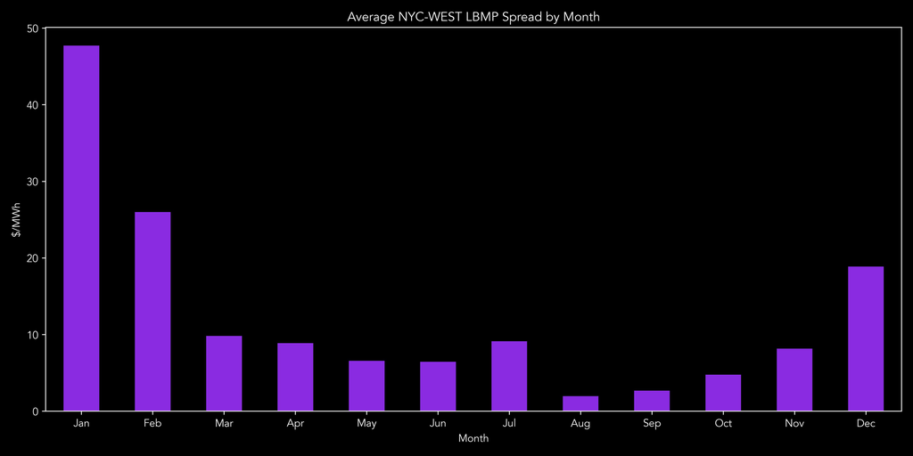

- **Average spread by hour** — elevated evening peaks, lowest at mid-morning

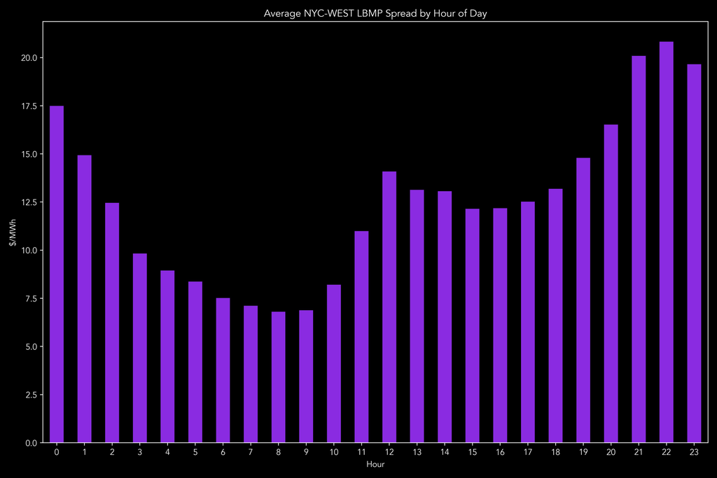

- **Single day view (March 3rd 2026)** — intraday congestion pattern

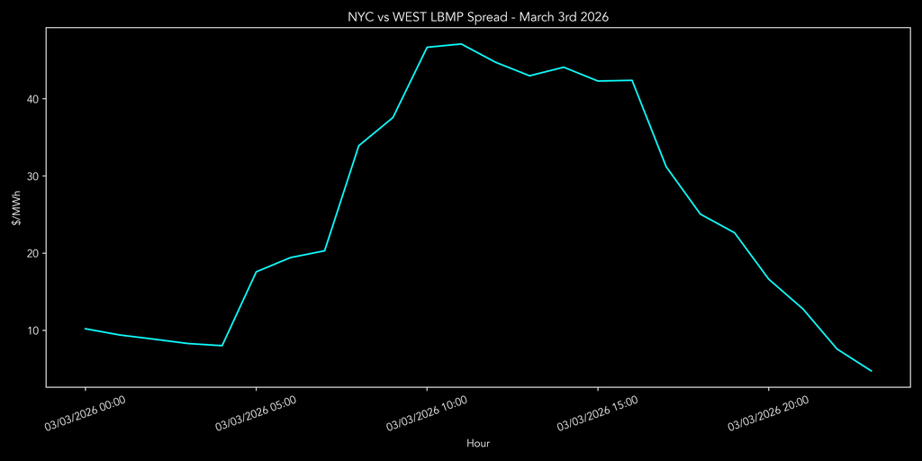

- **Feature importance** — Month >> Hour > Day of Week > Weekend

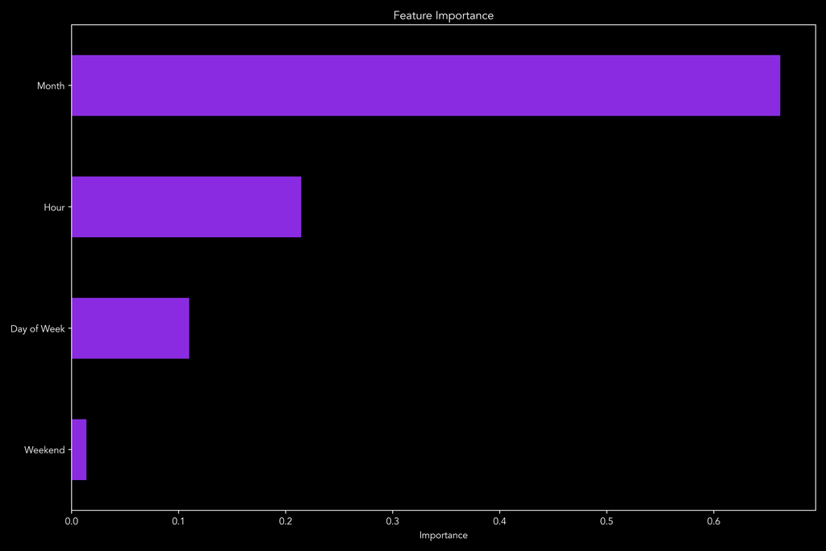

- **Predicted v.s. Actual LBMP Spread** - demonstration of model inacuracy

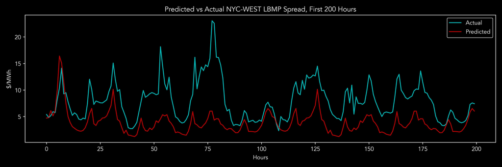

## Workflow

Data wrangling and visualisation were written in Python using the pandas, matplotlib, and numpy modules. The random forest model was built using scikit-learn.

## Structure

```
├── Clean/
│   └── 2025_LBMP_clean.csv
│   └── 20260303damlbmp_zone.csv
├── 2025 Monthly LBMP/   # raw daily CSVs
├── Plots/
│   └── plot_1.jpg
│   └── plot_2.jpg
│   └── plot_3.jpg
│   └── plot_4.jpg
│   └── plot_5.jpg
├── cleaner.py           # data pipeline and cleaning
├── primary.py           # analysis and modelling
└── index.html           # readme
```

## How to Run

1. Make sure `2025 Monthly LBMP/`contains raw Zonal Day-Ahead Market LBMP NYISO CSVs
2. Run `cleaner.py` to generate cleaned dataset, this is saved under `Clean/`
3. Run `primary.py` to reproduce model output and plots (saved in `Plots`)

## Required Packages

- numpy
- matplotlib
- scikit-learn
- pandas

## Potential Next Steps

- Expand use of other datasets to test additional prediction variables
- Expand original dataset to include more years, run analysis on individual years, etc.
- Explore other types of regression models
- Improve aesthetics of plots